# Homework 3 - Ujwala Musku

### Load Libraries

```python
from PIL import Image
import numpy as np
import random
from numpy.linalg import eig
import matplotlib.pyplot as plt
import IPython.display as ipd
from scipy.io import wavfile
from numpy import linalg as la
import math
import librosa
```

# P1: DCT and PCA

### Load the image

```python
img = Image.open("data/IMG_1878.JPG")
np_img = np.array(img)
```

### Extracting the red, green, and blue channels

```python
x_r = np_img[...,0]
x_g = np_img[...,1]
x_b = np_img[...,2]
print("Shape of the red channel:",x_r.shape)
print("Shape of the green channel:",x_g.shape)
print("Shape of the blue channel:",x_b.shape)
```

```
Shape of the red channel: (1024, 768)
Shape of the green channel: (1024, 768)
Shape of the blue channel: (1024, 768)
```

### Function to generate the R matrix

```python
def R_gen(iterations):
    R = np.zeros((8, x_r.shape[1])) # initialize
    for each in [x_r,x_g,x_b]: # for each of the channel
        for i in range(iterations): # number of iterations
            rand_val = random.randint(0, each.shape[0]-8)
            b = each[rand_val:rand_val+8,0:each.shape[1]]
            R = np.hstack((R,b))
    R = R[:,768:] #removing the initial zeros used for initializing and appending purposes
    return R
```

### Function to subtract the mean vector and calculate the co-variance vector

```python
def covar(R):
    mu_mat = np.mean(R,axis=1).reshape((8,1))
    R = R - mu_mat
    co_var = np.cov(R)
    return co_var
```

### Function to define a DCT matrix

```python
def dct_matrix(N):
    const = N**(-0.5)
    dct_mat = np.zeros((8,8))
    for n in range(N):
        for k in range(N):
            cosine_val = np.cos((np.pi/(2*N))*k*(2*n+1))
            dct_mat[k,n] = cosine_val*const

    return dct_mat
dct_mat = dct_matrix(8)
```

### Function to plot the spectogram

```python
def plot(vector,string,position):
    for i in range(len(vector)):
        ax[i,position].plot(vector[i])
    ax[0,position].set_title(string)
```

## 3 iterations per each channel

```python
# R matrix generation
iterations = 3
R = R_gen(iterations)
print("Shape of the R matrix",R.shape)

# Co-variance Matrix calculation
co_var = covar(R)
print("Shape of the covariance matrix:",co_var.shape)

# Eigen Decomposition
values_3, vectors_3 = eig(co_var) # using linalg library to calculate the eigen vectors and eigen values
```

```
Shape of the R matrix (8, 6912)
Shape of the covariance matrix: (8, 8)
```

### Plot the spectogram of transposed eigen vector after 9 iterations

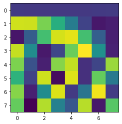

```python
plt.imshow(vectors_3.T)
```

### Spectogram of DCT Matrix

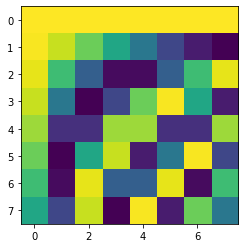

```python
plt.imshow(dct_mat)
```

## 30 iterations per each channel

```python
# Using the R generation function for 90 iterations
iterations = 30
R = R_gen(iterations)
print("Shape of R matrix:",R.shape)

#### Subtracting the mean vector and calculating the covariance again for 90 iterations
mu_mat = np.mean(R,axis=1).reshape((8,1))
R = R - mu_mat
co_var = np.cov(R)
print("Shape of the covariance matrix:",co_var.shape)

# Eigen Decomposition
values_30, vectors_30 = eig(co_var)
```

```
Shape of R matrix: (8, 69120)
Shape of the covariance matrix: (8, 8)
```

### Plot the spectogram of transposed eigen vector after 90 iterations

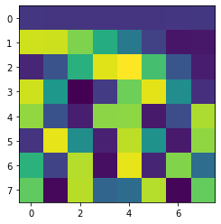

```python
plt.imshow(vectors_30.T)
```

```python
print("Difference between DCT Matrix and 9 iteration:",np.sum(np.subtract(dct_mat,vectors_3.T)))
print("Difference between DCT Matrix and 90 iteration:",np.sum(np.subtract(dct_mat,vectors_30.T)))
```

```
Difference between DCT Matrix and 9 iteration: 5.6700163601216085
Difference between DCT Matrix and 90 iteration: 5.674139434849398
```

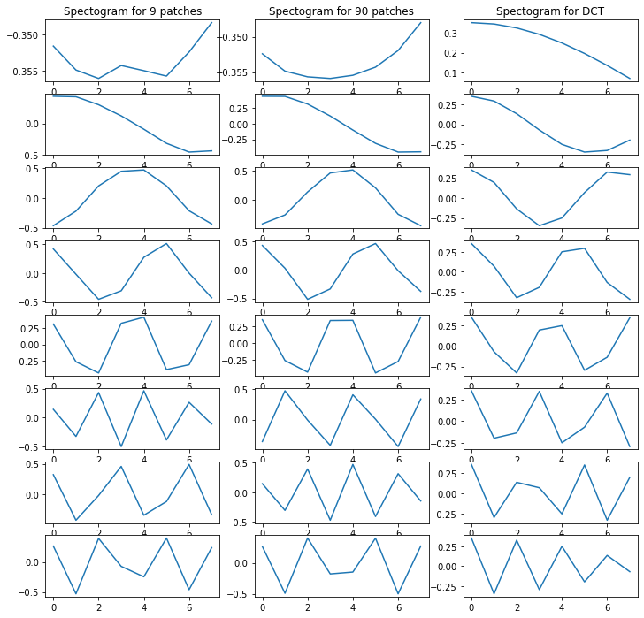

```python
fig, ax = plt.subplots(8, 3)
fig.set_figheight(12)
fig.set_figwidth(12)

plot(vectors_3.T,"Spectogram for 9 patches",0)
plot(vectors_30.T,"Spectogram for 90 patches",1)
plot(dct_mat.T,"Spectogram for DCT",2)
```

# P2: Instantaneous Source Separation

### Read the audio files and normalize

```python
samplerate, x1 = wavfile.read('data/x_ica_1.wav')
samplerate, x2 = wavfile.read('data/x_ica_2.wav')
samplerate, x3 = wavfile.read('data/x_ica_3.wav')
samplerate, x4 = wavfile.read('data/x_ica_4.wav')

for each in [x1,x2,x3,x4]:  # normalizing each of the audio file
    each = each/la.norm(each)

X = np.vstack((x1,x2,x3,x4)) # stacking up all the four audio files
print("Shape of matrix X:",X.shape)
```

```
Shape of matrix X: (4, 42292)
```

# ICA Algorithm

### 1. Covariance of the X matrix

```python
co_var = np.cov(X)
print("Shape of the co-variance matrix of X:",co_var.shape)
```

```
Shape of the co-variance matrix of X: (4, 4)
```

### 2. Eigen Decomposition

```python
lmda, W = eig(co_var) # lmda is the eigen value and W is the eigen vector
print("Eigen Values:",lmda)
print("Eigen vectors:", W)
```

```
Eigen Values: [6.06133015e+07 2.15615123e+05 1.78100905e+03 1.18721807e+02]
Eigen vectors: [[-0.56492946  0.13555186 -0.57704041 -0.57402505]
 [-0.48582951 -0.1043899   0.79567441 -0.3463736 ]
 [-0.64508182  0.21253735 -0.04714705  0.73244418]
 [-0.16939255 -0.96205838 -0.17805549  0.11851619]]
```

#### The below plot below ideally suggests us to identify the elbow and choose the eigen values and corresponding eigen vectors to reduce dimensions. But in this use-case, we don't reduce the number of dimensions because we want to recover all the four sources

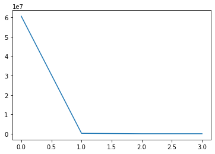

```python
plt.plot(lmda)
```

### 3. Whitening PCA

```python
Z = (np.linalg.inv(np.diag(lmda)**(0.5)) @ (W.T)) @ X
print(Z)
```

```
[[-5.60708782e-01 -8.58975938e-01 -6.53037311e-01 ...  1.52355848e+00
   1.65481376e+00  1.70277193e+00]
 [ 8.81510363e-02  1.22238338e-01  8.76583063e-02 ... -2.14671947e-01
  -2.23842678e-01 -2.39947509e-01]
 [ 1.76911236e-02  2.76730494e-02  7.02976835e-04 ... -5.35230781e-02
  -5.15496309e-02 -7.13046179e-02]
 [ 3.92191970e-02 -6.23993034e-04 -4.63126873e-02 ... -2.76989319e-02
  -1.43554569e-02 -8.85054731e-02]]
```

### 4. Updation of unmixing matrix

### Initialization

```python
N = Z.shape[1]
I = np.identity(Z.shape[0]) #identity matrix
rho = 0.000001 #learning rate
W = np.random.rand(Z.shape[0],Z.shape[0]) # initialzing with random values
Y = W@Z
del_W = math.inf # initializing delta W
```

```python
while np.sum(np.abs(del_W)) > 0.0000001:
    f_Y = Y**3 # non-linear function 1
    g_Y = np.tanh(Y) # non-linear function 2
    del_W = (N*I - (g_Y @ f_Y.T))@W # calculating the difference
    W += rho * del_W #update the W
    Y = W @ Z
X = W@Z #recovered signal with 4 sources
```

### 5. Recovered Signal

```python
ipd.Audio(X[0],rate = samplerate)
```

[interactive chart not shown]

```python
ipd.Audio(X[1],rate = samplerate)
```

[interactive chart not shown]

```python
ipd.Audio(X[2],rate = samplerate)
```

[interactive chart not shown]

```python
ipd.Audio(X[3],rate = samplerate)
```

[interactive chart not shown]

# P3: Ideal Masks

### Load Ocean audio

```python
ipd.Audio('data/ocean.wav')
```

[interactive chart not shown]

### Load Piano audio

```python
ipd.Audio('data/piano.wav')
```

[interactive chart not shown]

### Loading the wave files using Librosa library with sample rate as native ones

```python
# samplerate, ocean = wavfile.read('data/ocean.wav')
# samplerate, piano = wavfile.read('data/piano.wav')
ocean, samplerate = librosa.load('data/ocean.wav', sr=None) #ocean
piano, samplerate = librosa.load('data/piano.wav', sr=None) #piano
```

```python
print("Shape of piano audio matrix:",piano.shape)
print("Shape of ocean audio matrix:",ocean.shape)
```

```
Shape of piano audio matrix: (80000,)
Shape of ocean audio matrix: (80000,)
```

## Short Time Fourier Transform

```python
N = 1024 #number of point frames
```

### Hannwindow

```python
hann_window = np.zeros((N,1))
for n in range(N):
    hann_window[n] = (np.sin(np.pi*n/N))**2
```

### Function to implement DFT Matrix

```python
def dft_mat(N,mul):
    F = np.zeros((N, N),dtype=complex)
    for f in range(N):
        for n in range(N):
            F[f][n] = np.exp(mul*2*np.pi*f*n/N * 1j)
    return F
F = dft_mat(N,-1)
```

### Function to implement STFT

```python
def stft(x):
    X = np.ones((N,1))
    index =0
    start, end = 0, N
    while end <= x.shape[0]:
        sub_x = x[np.int64(start):np.int64(end)].reshape((N,1))
        col = sub_x * hann_window
        X=np.concatenate((X,col),axis=1)
        start+=N/2
        end+=N/2
        index+=1
    X=np.delete(X,0,axis = 1)
    res = F @ X
    #f_res = res[0:((N//2)+1),:]
    return res,X
```

### Inverse STFT Function

```python
def istft(new_S):
    F_star = dft_mat(N,1)/N
    X_hat = np.dot(F_star,new_S)
    result_pad = X_hat[:,0].reshape((N,1)).T
    i=1

    while i < X_hat.shape[1]:
        t = X_hat[:,i].reshape((N,1)).T
        t_pad = np.pad(t, ((0,0),(i*np.int64(N/2),0)), mode='constant', constant_values=0)

        result_pad = np.pad(result_pad, ((0,0),(0,np.int64(N/2))), mode='constant', constant_values=0)
        result_pad += t_pad
        i+=1
    print("Shape of recovered signal after inversing:",result_pad.shape)
    return result_pad
```

### Spectogram of original, recovered, and mixed signal

```python
def spectogram_q3(X,new_S,p_res):
    fig, ax = plt.subplots(2, 2)
    fig.set_figheight(18)
    fig.set_figwidth(18)
    ax[0,0].imshow(np.absolute(p_res),aspect='auto')
    ax[0,0].set_title("S (Initial piano)")

    ax[0,1].imshow(np.absolute(X),aspect='auto')
    ax[0,1].set_title("X (Mixed signal - piano and ocean)")

    ax[1,0].imshow(np.absolute(new_S),aspect='auto')
    ax[1,0].set_title("Recovered S after masking (M_bar)")

    ax[1,1].imshow(np.absolute(X),aspect='auto')
    ax[1,1].set_title("X (Mixed signal - piano and ocean)")
```

### Function to calculate SNR value

```python
def snr(r_sh_piano,re):
    numerator = r_sh_piano.T @ r_sh_piano
    denominator = (r_sh_piano - re).T @ (r_sh_piano - re)
    snr = 10 * np.log10(np.divide(numerator,denominator))
    return snr
```

### Function to calculate M_bar masking

```python
# Calculation of M_bar matrix
def m_bar(piano_res,ocean_res):
    num = np.absolute(piano_res)**2
    den = np.absolute(ocean_res)**2+np.absolute(piano_res)**2
    M_bar = np.divide(num,den)
    print("Shape of M_bar matrix:",M_bar.shape)
    return M_bar
```

### Function to implement IBM

```python
def ibm(piano_res,ocean_res):
    B = np.zeros((piano_res.shape))
    for row in range(piano_res.shape[0]):
        for col in range(piano_res.shape[1]):
            if np.absolute(piano_res[row,col]) > np.absolute(ocean_res[row,col]):
                B[row,col] = 1
        else:
            B[row,col] = 0

    print("Shape of the B matrix:",B.shape)
    return B
```

### Spectogram of the real part of DFT matrix

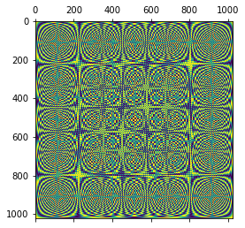

```python
plt.matshow(F.real,aspect='auto')
```

### Applying STFT to both piano and ocean audio

```python
o_res,o_X = stft(ocean)
p_res,p_X = stft(piano)
```

### Removing the complex conjugates

```python
ocean_res = o_res[0:((N//2)+1),:]
piano_res = p_res[0:((N//2)+1),:]
```

### Mixture signal

```python
X = ocean_res + piano_res
print("Shape of the mixture signal:",X.shape)
```

```
Shape of the mixture signal: (513, 155)
```

### Masking using M_bar

```python
M_bar = m_bar(piano_res,ocean_res)

# Recovering the signal
new_S = M_bar * X

# Regaining the shape of recovered signal by joining the complex conjugate part
new_S = np.vstack((new_S,p_res[((N//2)+1):N,:]))
print("Shape of the recovered signal after stacking the complex conjugate part before inversing:",new_S.shape)
```

```
Shape of M_bar matrix: (513, 155)
Shape of the recovered signal after stacking the complex conjugate part before inversing: (1024, 155)
```

### Inverse STFT

```python
recovered_piano = istft(new_S)
```

```
Shape of recovered signal after inversing: (1, 79872)
```

### Recovered audio after M_bar masking

```python
print("After M_bar Masking - Recovered signal")
ipd.Audio(recovered_piano.real, rate = samplerate)
```

```
After M_bar Masking - Recovered signal
```

[interactive chart not shown]

## Spectogram of original, recovered, and mixed signal - Masking with M_bar

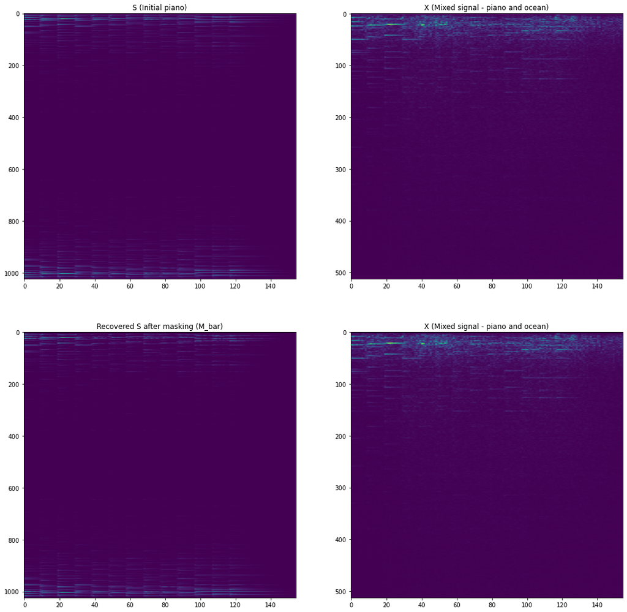

```python
spectogram_q3(X,new_S,p_res)
```

### SNR value (M_bar masking)

```python
### Making sure the length of both the original and recovered signal shape is same
r_sh_piano = piano[0:79872].real
print("Shape of the original piano audio:",r_sh_piano.shape)

re = np.squeeze(np.asarray(recovered_piano)).real
print("Shape of the recovered piano audio:",re.shape)

snr_m_bar = snr(r_sh_piano,re)
print("SNR value of piano after masking with M_bar and recovering it back:",snr_m_bar)
```

```
Shape of the original piano audio: (79872,)
Shape of the recovered piano audio: (79872,)
SNR value of piano after masking with M_bar and recovering it back: 13.901245575442916
```

## IBM Calculation

```python
B = ibm(piano_res,ocean_res)
S_im = B * X
```

```
Shape of the B matrix: (513, 155)
```

```python
S_im = np.vstack((S_im,p_res[((N//2)+1):N,:]))
recovered_pi_ibm = istft(S_im)
re_ibm = np.squeeze(np.asarray(recovered_pi_ibm)).real

snr_ibm = snr(r_sh_piano,re_ibm)
print("SNR value of piano after masking with IBM and recovering it back:",snr_ibm)
```

```
Shape of recovered signal after inversing: (1, 79872)
SNR value of piano after masking with IBM and recovering it back: 12.82366690708524
```

```python
print("After IBM Masking - Recovered signal")
ipd.Audio(recovered_pi_ibm.real, rate = samplerate)
```

```
After IBM Masking - Recovered signal
```

[interactive chart not shown]

## Spectogram of original, recovered, and mixed signal - Masking with IBM

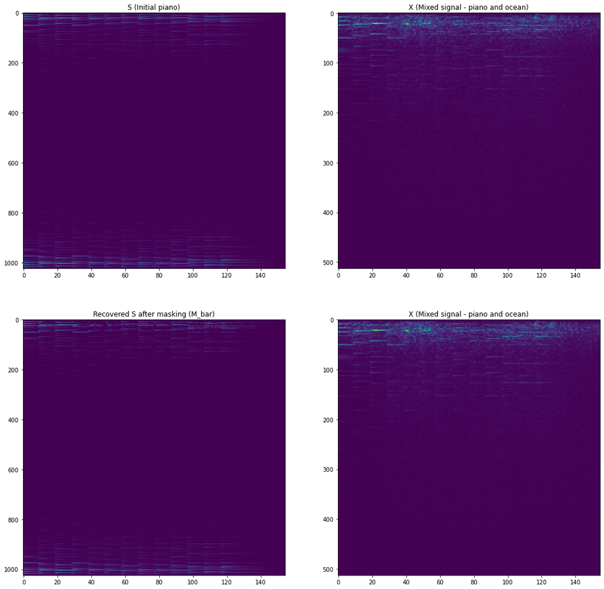

```python
spectogram_q3(X,S_im,p_res)
```

#### Both the recovered piano sounds from M_bar and IBM masking are very similar to the original piano sound. As SNR value increases, the better the quality of the sound. Hence, the signal with M_bar sounds slightly better than IBM

### After using my own STFT and ISTFT implementation, though I was able to recover the signal properly, I didn't get the SNR value after M_bar and IBM masking in the range of 8 and 7. Hence, I used the library librosa to implement stft and istft again.

```python
lb_piano = librosa.stft(piano,n_fft = 1024, hop_length = 512, window='hann',center=True, pad_mode='constant')
lb_ocean = librosa.stft(ocean,n_fft = 1024, hop_length = 512, window='hann',center=True, pad_mode='constant')

lb_X = lb_piano + lb_ocean
print("Shape of the mixture signal using Librosa:",lb_X.shape)

print("Using M_bar masking - Librosa")
# M_bar calculation
M_bar = m_bar(lb_piano,lb_ocean)

# Recovering the signal
new_S = M_bar * lb_X

# Recovered piano sound after inversing - M_bar masking
recovered_piano = librosa.istft(new_S, hop_length = 512,center=True)
ipd.Audio(recovered_piano.real, rate = samplerate)
```

```
Shape of the mixture signal using Librosa: (513, 157)
Using M_bar masking - Librosa
Shape of M_bar matrix: (513, 157)
```

[interactive chart not shown]

```python
print("Using IBM masking - Librosa")
# IBM Calculation
B = ibm(lb_piano,lb_ocean)

# Recovering the signal
S_im = B * lb_X

# Recovered piano sound after inversing - IBM masking
recovered_pi_ibm = librosa.istft(S_im, hop_length = 512,center=True)
ipd.Audio(recovered_piano.real, rate = samplerate)
```

```
Using IBM masking - Librosa
Shape of the B matrix: (513, 157)
```

[interactive chart not shown]

```python
### Making sure the length of both the original and recovered signal shape is same
r_sh_piano = piano[0:79872].real
print("Shape of the original piano audio:",r_sh_piano.shape)

re = np.squeeze(np.asarray(recovered_piano)).real
print("Shape of the recovered piano audio:",re.shape)

re_ibm = np.squeeze(np.asarray(recovered_pi_ibm)).real

snr_m_bar = snr(r_sh_piano,re)
print("SNR value of piano after masking with M_bar and recovering it back:",snr_m_bar)

snr_ibm = snr(r_sh_piano,re_ibm)
print("SNR value of piano after masking with IBM and recovering it back:",snr_ibm)
```

```
Shape of the original piano audio: (79872,)
Shape of the recovered piano audio: (79872,)
SNR value of piano after masking with M_bar and recovering it back: 8.116030097007751
SNR value of piano after masking with IBM and recovering it back: 7.374317599878042
```